# codingru

```r
police_data <- read_csv(here("data/Innocent Deaths caused by Police (All time).csv"))
head(police_data)
```

```
## # A tibble: 6 × 27
##   `Unique ID` Name       Age Gender Race    `URL of image` `Date of injury resu…
##         <dbl> <chr>    <dbl> <chr>  <chr>   <chr>          <chr>
## 1       25747 Mark A.…    21 Male   Africa… <NA>           1/1/2000
## 2       25748 Phillip…    19 Male   Africa… <NA>           1/1/2000
## 3       25746 Samuel …    17 Male   Europe… <NA>           1/1/2000
## 4       25749 Mark Or…    23 Male   Hispan… <NA>           1/1/2000
## 5           1 LaTanya…    24 Female Africa… <NA>           1/2/2000
## 6           2 Lester …    53 Male   Race u… <NA>           1/2/2000
## # … with 20 more variables: Location of injury (address) <chr>,
## #   Location of death (city) <chr>, State <chr>,
## #   Location of death (zip code) <dbl>, Location of death (county) <chr>,
## #   Full Address <chr>, Latitude <dbl>, Longitude <dbl>,
## #   Agency or agencies involved <chr>, Highest level of force <chr>,
## #   Alleged weapon <chr>, Aggressive physical movement <chr>,
## #   Fleeing/Not fleeing <chr>, Description Temp <chr>, URL Temp <lgl>, …
```

```r
set.seed(32)
police_split <- initial_split(police_data, prop = 0.8)
train_data <- training(police_split)
test_data <- testing(police_split)
```

```r
police_data <- read_csv(here("data/Innocent Deaths caused by Police (All time).csv"))
head(police_data)
```

```
## # A tibble: 6 × 27
##   `Unique ID` Name       Age Gender Race    `URL of image` `Date of injury resu…
##         <dbl> <chr>    <dbl> <chr>  <chr>   <chr>          <chr>
## 1       25747 Mark A.…    21 Male   Africa… <NA>           1/1/2000
## 2       25748 Phillip…    19 Male   Africa… <NA>           1/1/2000
## 3       25746 Samuel …    17 Male   Europe… <NA>           1/1/2000
## 4       25749 Mark Or…    23 Male   Hispan… <NA>           1/1/2000
## 5           1 LaTanya…    24 Female Africa… <NA>           1/2/2000
## 6           2 Lester …    53 Male   Race u… <NA>           1/2/2000
## # … with 20 more variables: Location of injury (address) <chr>,
## #   Location of death (city) <chr>, State <chr>,
## #   Location of death (zip code) <dbl>, Location of death (county) <chr>,
## #   Full Address <chr>, Latitude <dbl>, Longitude <dbl>,
## #   Agency or agencies involved <chr>, Highest level of force <chr>,
## #   Alleged weapon <chr>, Aggressive physical movement <chr>,
## #   Fleeing/Not fleeing <chr>, Description Temp <chr>, URL Temp <lgl>, …
```

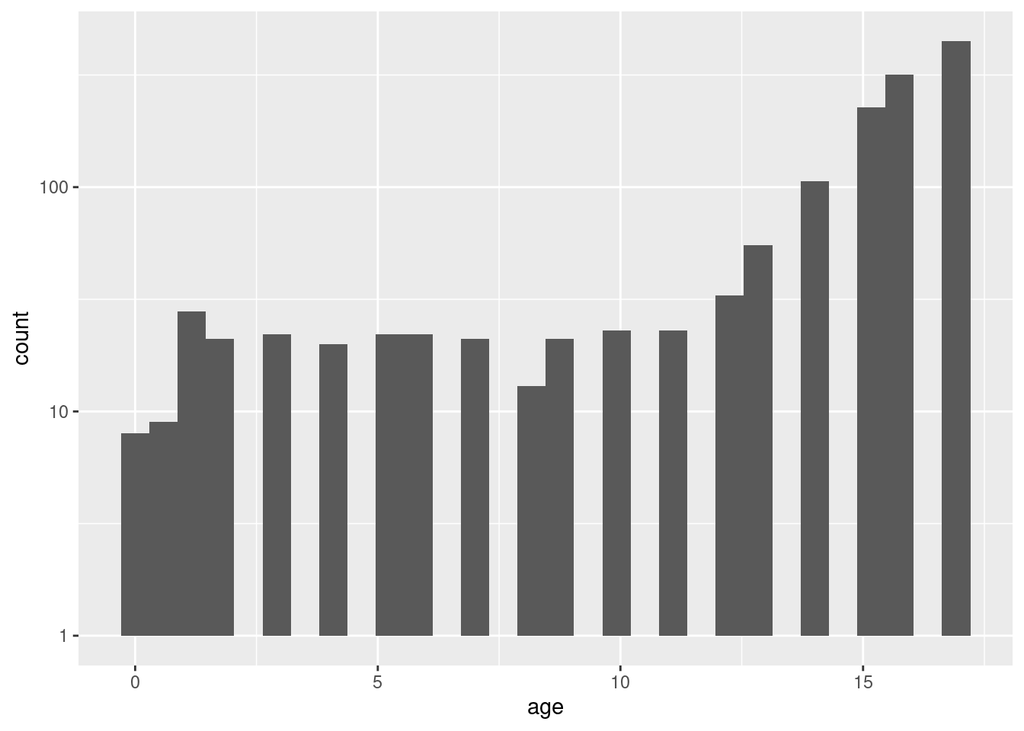

```r
police_data <- subset(police_data, select = -c(6, 8, 13, 21, 22, 23, 26))
police_data <- rename(police_data, unique_id = `Unique ID`, name = Name, age = Age, gender = Gender, race = Race, doi = `Date of injury resulting in death (month/day/year)`, state = State, lod_zip_code = `Location of death (zip code)` , lod_county = `Location of death (county)`, latitude = Latitude, longitude = Longitude,  agency_involved = `Agency or agencies involved`, hlof = `Highest level of force`, alleged_weapon = `Alleged weapon`, agressive_movement = `Aggressive physical movement`, fleeing_not_fleeing = `Fleeing/Not fleeing`, dispositions_exclusions =`Dispositions/Exclusions INTERNAL USE, NOT FOR ANALYSIS`, iuof = `Intended use of force (Developing)`, mental_illness = `Foreknowledge of mental illness`)
police_data1 <- police_data %>%
  filter(age < 18)
ggplot(police_data1,
       aes(x = age)) +
  geom_histogram() +
  scale_y_log10()
```

```r
linear_reg() %>%
  set_engine("lm") %>%
  fit(age ~ race, data = police_data) %>%
  tidy()
```

```
## # A tibble: 8 × 5
##   term                        estimate std.error statistic   p.value
##   <chr>                          <dbl>     <dbl>     <dbl>     <dbl>
## 1 (Intercept)                   31.4       0.164   191.    0
## 2 raceAsian/Pacific Islander     3.28      0.641     5.12  3.03e-  7
## 3 raceeuropean-American/White   -7.36     13.5      -0.544 5.86e-  1
## 4 raceEuropean-American/White    6.83      0.211    32.4   3.08e-226
## 5 raceHispanic/Latino            0.526     0.270     1.95  5.10e-  2
## 6 raceMiddle Eastern            -0.297     1.90     -0.156 8.76e-  1
## 7 raceNative American/Alaskan   -0.425     0.779    -0.546 5.85e-  1
## 8 raceRace unspecified           5.36      0.225    23.9   1.03e-124
```

```r
linear_reg() %>%
  set_engine("lm") %>%
  fit(age ~ agressive_movement, data = police_data) %>%
  tidy()
```

```
## # A tibble: 24 × 5
##    term                                    estimate std.error statistic  p.value
##    <chr>                                      <dbl>     <dbl>     <dbl>    <dbl>
##  1 (Intercept)                               38.0       0.426   89.2    0
##  2 agressive_movementAdvanced upon office…   -3.88      3.74    -1.04   2.99e- 1
##  3 agressive_movementBrandished weapon        0.404     0.500    0.809  4.18e- 1
##  4 agressive_movementDuplicate of 13419?      1.05     13.9      0.0753 9.40e- 1
##  5 agressive_movementDuplicate of 13457?     35.0      13.9      2.52   1.17e- 2
##  6 agressive_movementEdged weapon/Unspeci…  -15.0      13.9     -1.08   2.82e- 1
##  7 agressive_movementIntentional vehicula…   -0.657     1.94    -0.339  7.35e- 1
##  8 agressive_movementNone                    -4.86      0.486  -10.0    1.93e-23
##  9 agressive_movementNone.                   -8.95     13.9     -0.644  5.19e- 1
## 10 agressive_movementNone. Police alleged…   -1.45      9.83    -0.148  8.83e- 1
## # … with 14 more rows
```

```r
linear_reg() %>%
  set_engine("lm") %>%
  fit(age ~ gender, data = police_data) %>%
  tidy()
```

```
## # A tibble: 3 × 5
##   term              estimate std.error statistic p.value
##   <chr>                <dbl>     <dbl>     <dbl>   <dbl>
## 1 (Intercept)         35.4       0.257   137.      0
## 2 genderMale          -0.110     0.271    -0.405   0.686
## 3 genderTransgender   -4.67      2.96     -1.58    0.114
```

```r
#police_race_zip <- police_data %>%
 # mutate("firstzip" = str_sub(lod_zip_code, -5,-5)) %>%
  #group_by(race, firstzip, year)

#ggplot(police_race_zip,
 #      aes(x = race),
  #     y = zip,
   #    colour = race)
```

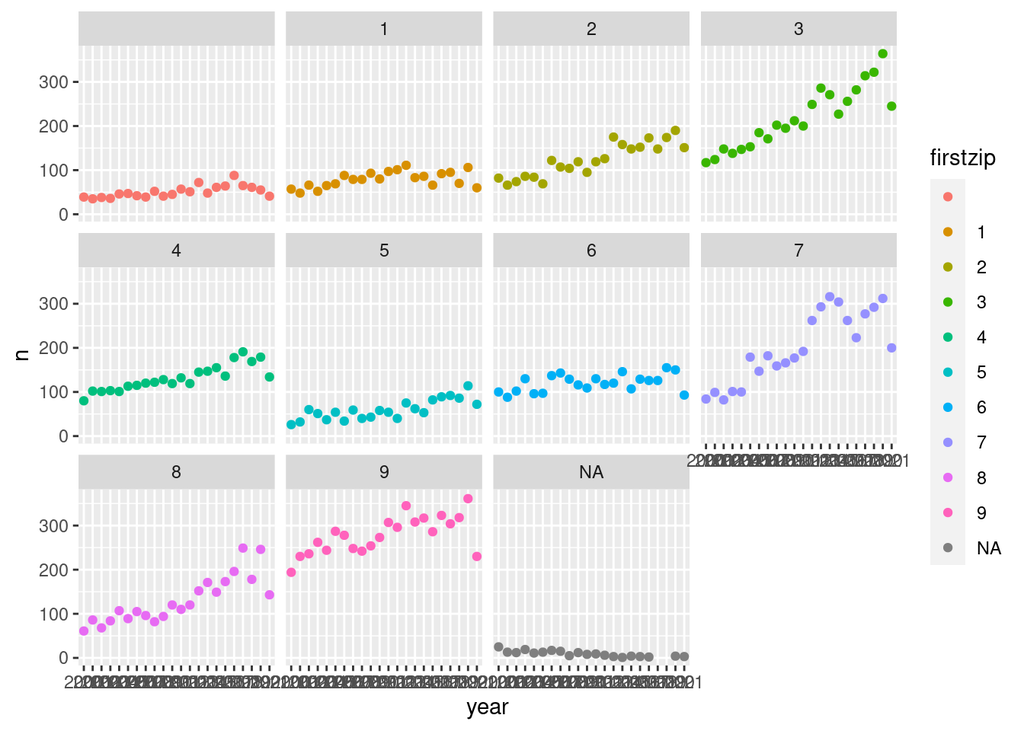

```r
police_zip <- police_data %>%
  mutate("firstzip" = str_sub(lod_zip_code, -5,-5)) %>%
   mutate(year = str_sub(doi,-4,-1)) %>%
  group_by(firstzip, year) %>%
  count(year)

ggplot(police_zip,
       aes(x = year,
           y = n,
           colour = firstzip)) +
  geom_point() +
  facet_wrap(~ firstzip)
```

We can see the general trend is increasing up till recently, this may be becuase of corona virus. However these results are interesting because (look up populations of the different numbers because they all look quite similar, so data on populations can be revealing) zip code zone picture [https://www.google.com/search?q=first+digit+zip+code+map&client=avast-a-1&sxsrf=AOaemvIfjvSPwTFnTZg8yUpp9bTWMuvZCg:1637760678673&source=lnms&tbm=isch&sa=X&ved=2ahUKEwjzs-r7jbH0AhVQ4aQKHbjUB3UQ_AUoAXoECAEQAw&biw=1280&bih=577&dpr=1.5#imgrc=mya_FV0kn9TnwM] information from [https://en.wikipedia.org/wiki/ZIP_Code#Primary_state_prefixes] The first digit of the zip code is allocated as follows: 0 = Connecticut (CT), Massachusetts (MA), Maine (ME), New Hampshire (NH), New Jersey (NJ), New York (NY, Fishers Island only), Puerto Rico (PR), Rhode Island (RI), Vermont (VT), Virgin Islands (VI) 1 = Delaware (DE), New York (NY), Pennsylvania (PA) 2 = District of Columbia (DC), Maryland (MD), North Carolina (NC), South Carolina (SC), Virginia (VA), West Virginia (WV) 3 = Alabama (AL), Florida (FL), Georgia (GA), Mississippi (MS), Tennessee (TN), Army Post Office Americas (APO AA), Fleet Post Office Americas (FPO AA) 4 = Indiana (IN), Kentucky (KY), Michigan (MI), Ohio (OH) 5 = Iowa (IA), Minnesota (MN), Montana (MT), North Dakota (ND), South Dakota (SD), Wisconsin (WI) 6 = Illinois (IL), Kansas (KS), Missouri (MO), Nebraska (NE) 7 = Arkansas (AR), Louisiana (LA), Oklahoma (OK), Texas (TX) 8 = Arizona (AZ), Colorado (CO), Idaho (ID), New Mexico (NM), Nevada (NV), Utah (UT), Wyoming (WY) 9 = Alaska (AK), American Samoa (AS), California (CA), Guam (GU), Hawaii (HI), Marshall Islands (MH), Federated States of Micronesia (FM), Northern Mariana Islands (MP), Oregon (OR), Palau (PW), Washington (WA)

[figure not shown]

```r
police_zip_reg <- police_data %>%
  mutate("firstzip" = str_sub(lod_zip_code, -5,-5)) %>%
   mutate(year = str_sub(doi,-4,-1)) %>%
  group_by(firstzip)

linear_reg() %>%
  set_engine("lm") %>%
  fit(year ~ firstzip, data = police_zip_reg) %>%
  tidy()
```

```
## # A tibble: 10 × 5
##    term        estimate std.error statistic     p.value
##    <chr>          <dbl>     <dbl>     <dbl>       <dbl>
##  1 (Intercept) 2012.        0.181 11109.    0
##  2 firstzip1     -0.359     0.232    -1.55  0.122
##  3 firstzip2      0.695     0.215     3.23  0.00124
##  4 firstzip3      0.758     0.201     3.77  0.000164
##  5 firstzip4      0.158     0.213     0.741 0.459
##  6 firstzip5      0.824     0.247     3.34  0.000839
##  7 firstzip6     -0.606     0.216    -2.81  0.00501
##  8 firstzip7      1.05      0.203     5.19  0.000000216
##  9 firstzip8      1.13      0.213     5.27  0.000000134
## 10 firstzip9     -0.420     0.197    -2.13  0.0329
```

```r
police_data1
```

```
## # A tibble: 1,440 × 20
##    unique_id name     age gender race  doi   `Location of de… state lod_zip_code
##        <dbl> <chr>  <dbl> <chr>  <chr> <chr> <chr>            <chr>        <dbl>
##  1     25746 Samue…    17 Male   Euro… 1/1/… Willits          CA           95490
##  2     25756 John …    16 Male   Hisp… 1/10… Oakland Park     FL           33334
##  3        15 Guido…    17 Male   Race… 1/11… Tampa            FL           33612
##  4        24 Korti…    17 Male   Race… 1/17… Joliet           IL           60433
##  5        30 Timot…    14 Male   Race… 1/22… Benton           AR           72019
##  6     25758 Justi…    17 Male   Euro… 1/23… Raynham          MA            2767
##  7     25759 Eric …    17 Male   Euro… 1/23… Raynham          MA            2767
##  8     25760 Steve…    15 Male   Race… 1/26… San Antonio      TX           78251
##  9        37 Micha…    15 Male   Afri… 1/28… Jersey City      NJ            7305
## 10     19496 Basil…     1 Male   Race… 2/2/… Harrisburg       PA           17103
## # … with 1,430 more rows, and 11 more variables: lod_county <chr>,
## #   latitude <dbl>, longitude <dbl>, agency_involved <chr>, hlof <chr>,
## #   alleged_weapon <chr>, agressive_movement <chr>, fleeing_not_fleeing <chr>,
## #   dispositions_exclusions <chr>, iuof <chr>, mental_illness <chr>
```

```r
linear_reg() %>%
  set_engine("lm") %>%
  fit(age ~ state, data = police_data1) %>%
  tidy()
```

```
## # A tibble: 47 × 5
##    term        estimate std.error statistic  p.value
##    <chr>          <dbl>     <dbl>     <dbl>    <dbl>
##  1 (Intercept)   15.5        2.16     7.16  1.29e-12
##  2 stateAL       -2.88       2.32    -1.24  2.14e- 1
##  3 stateAR       -0.722      2.39    -0.302 7.63e- 1
##  4 stateAZ       -0.545      2.35    -0.232 8.17e- 1
##  5 stateCA       -1.48       2.19    -0.675 5.00e- 1
##  6 stateCO       -1.72       2.35    -0.732 4.64e- 1
##  7 stateCT       -4.00       2.79    -1.43  1.53e- 1
##  8 stateDC       -4.00       3.06    -1.31  1.92e- 1
##  9 stateDE        0.500      4.84     0.103 9.18e- 1
## 10 stateFL       -0.356      2.21    -0.161 8.72e- 1
## # … with 37 more rows
```

[figure not shown]

```r
#create a histogram with frequency and alleged weapon
```